# Ovarian Cancer Survival Data analysis

Your collaborator

The analysis presented is an exploration of the Survival in a randomised trial comparing two treatments for ovarian cancer Data Set available at the “survival” R package

# 1 Reading the data and learning its structure

Read and have a first look at the data

```r
df <- ovarian
str(df)
```

```
## 'data.frame':    26 obs. of  6 variables:
##  $ futime  : num  59 115 156 421 431 448 464 475 477 563 ...
##  $ fustat  : num  1 1 1 0 1 0 1 1 0 1 ...
##  $ age     : num  72.3 74.5 66.5 53.4 50.3 ...
##  $ resid.ds: num  2 2 2 2 2 1 2 2 2 1 ...
##  $ rx      : num  1 1 1 2 1 1 2 2 1 2 ...
##  $ ecog.ps : num  1 1 2 1 1 2 2 2 1 2 ...
```

According to the description given in the package, there are six columns that describe the data set

- futime: survival or censoring time
- fustat: censoring status
- age: in years
- resid.ds: residual disease present (1=no,2=yes)
- rx: treatment group
- ecog.ps: ECOG performance status (1 is better, see reference)

Let’s modify the data and look at variables in the details

For more convenient interpretation, one can convert obviously nominative variables into factors with two levels

```r
df$resid.ds <- factor(df$resid.ds,
                      levels = c(1, 2),
                      labels = c("No", "Yes"))
df$rx <- factor(df$rx,
                levels = c(1, 2),
                labels = c("First", "Second"))
df$ecog.ps <- factor(df$ecog.ps,
                     levels = c(1, 2),
                     labels = c("Good", "Bad"))
```

The futime column holds the survival times. This is the response variable. fustat, on the other hand, tells you if an individual patients’ survival time is censored

```r
summary(as.factor(df$fustat))
```

```
##  0  1
## 14 12
```

Apparently, the 26 patients in this study received either one of two therapy regimens

```r
summary(as.factor(df$rx))
```

```
##  First Second
##     13     13
```

And the attending physician assessed the regression of tumors

```r
summary(as.factor(df$resid.ds))
```

```
##  No Yes
##  11  15
```

Patients’ performance according to the standardized ECOG criteria

```r
summary(as.factor(df$ecog.ps))
```

```
## Good  Bad
##   14   12
```

Also, looking at the distribution of the Age variable one can identify rather clear division of the patients into two groups

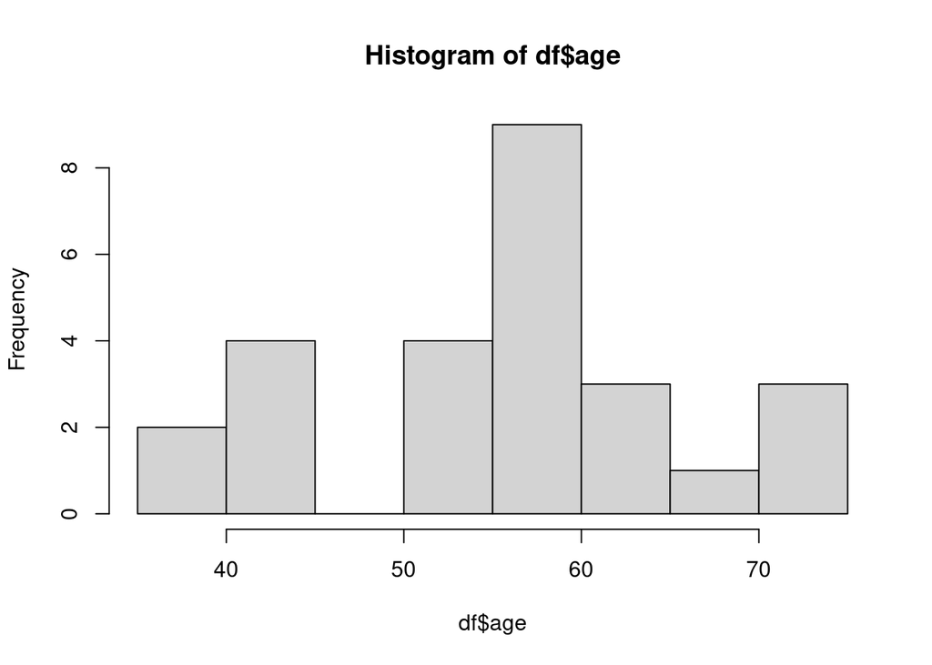

```r
hist(df$age, breaks = 10)
```

Thus, let’s create a new variable dividing investigated individuals into two groups “Elderly” and “Young”

```r
df <- df %>%
  mutate(age_group = ifelse(age >=50, "Elderly", "Young"))
df$age_group <- factor(df$age_group)
```

Summary of the modified dataframe

```r
summary(df)
```

```
##      futime           fustat            age        resid.ds      rx
##  Min.   :  59.0   Min.   :0.0000   Min.   :38.89   No :11   First :13
##  1st Qu.: 368.0   1st Qu.:0.0000   1st Qu.:50.17   Yes:15   Second:13
##  Median : 476.0   Median :0.0000   Median :56.85
##  Mean   : 599.5   Mean   :0.4615   Mean   :56.17
##  3rd Qu.: 794.8   3rd Qu.:1.0000   3rd Qu.:62.38
##  Max.   :1227.0   Max.   :1.0000   Max.   :74.50
##  ecog.ps     age_group
##  Good:14   Elderly:20
##  Bad :12   Young  : 6
##
##
##
##
```

# 2 Kaplan Meier Survival Curves building

Creation of the time scaling

```r
km <- with(df, Surv(futime, fustat))
km
```

```
##  [1]   59   115   156   421+  431   448+  464   475   477+  563   638   744+
## [13]  769+  770+  803+  855+ 1040+ 1106+ 1129+ 1206+ 1227+  268   329   353
## [25]  365   377+
```

Building a model and visualizing dependency of survival by the Age

```r
km_age_fit <- survfit(km ~ age_group, data=df)
km_age_fit
```

```
## Call: survfit(formula = km ~ age_group, data = df)
##
##                    n events median 0.95LCL 0.95UCL
## age_group=Elderly 20     11    563     431      NA
## age_group=Young    6      1     NA      NA      NA
```

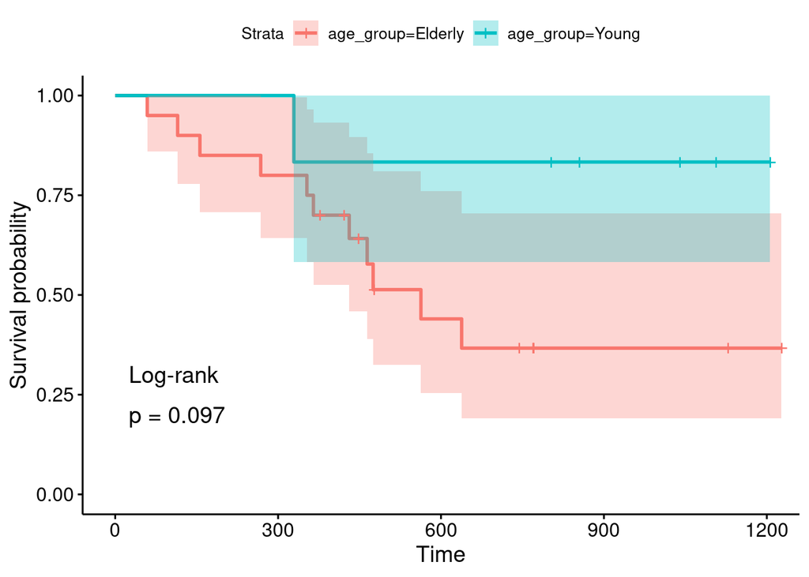

```r
ggsurvplot(km_age_fit, data = df, pval = TRUE, pval.method = TRUE, conf.int = TRUE)
```

Building a model and visualizing dependency of survival by the resid.ds

```r
km_resid_fit <- survfit(km ~ resid.ds, data=df)
km_resid_fit
```

```
## Call: survfit(formula = km ~ resid.ds, data = df)
##
##               n events median 0.95LCL 0.95UCL
## resid.ds=No  11      3     NA     638      NA
## resid.ds=Yes 15      9    464     329      NA
```

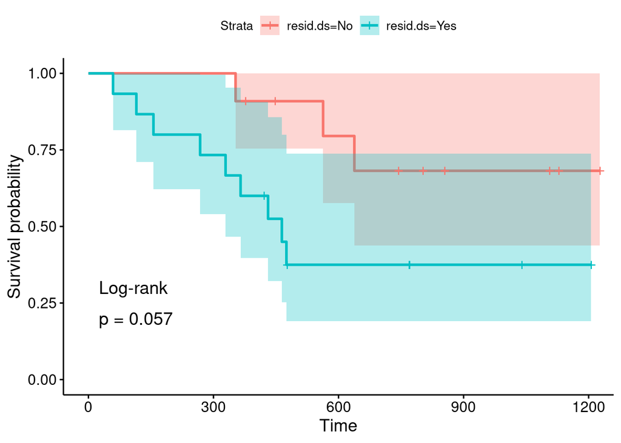

```r
ggsurvplot(km_resid_fit, data = df, pval = TRUE, pval.method = TRUE, conf.int = TRUE)
```

Building a model and visualizing dependency of survival by the rx status

```r
km_rx_fit <- survfit(km ~ rx, data=df)
km_rx_fit
```

```
## Call: survfit(formula = km ~ rx, data = df)
##
##            n events median 0.95LCL 0.95UCL
## rx=First  13      7    638     268      NA
## rx=Second 13      5     NA     475      NA
```

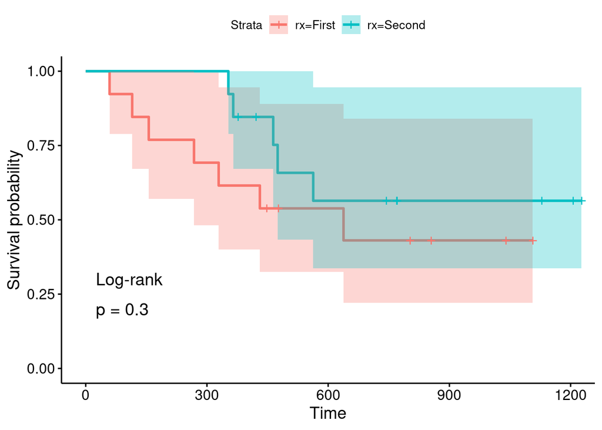

```r
ggsurvplot(km_rx_fit, data = df, pval = TRUE, pval.method = TRUE, conf.int = TRUE)
```

Building a model and visualizing dependency of survival by the ecog.ps status

```r
km_ecog_fit <- survfit(km ~ ecog.ps, data=df)
km_ecog_fit
```

```
## Call: survfit(formula = km ~ ecog.ps, data = df)
##
##               n events median 0.95LCL 0.95UCL
## ecog.ps=Good 14      5     NA     431      NA
## ecog.ps=Bad  12      7    563     464      NA
```

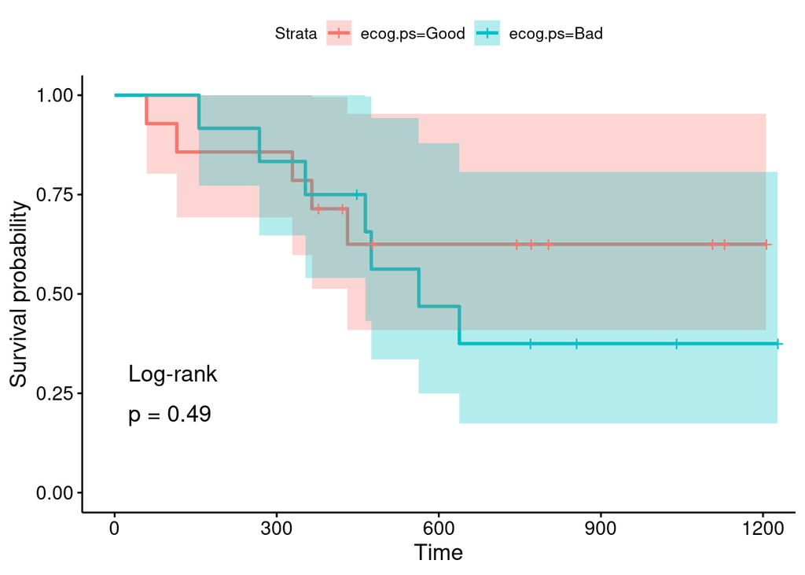

```r
ggsurvplot(km_ecog_fit, data = df, pval = TRUE, pval.method = TRUE, conf.int = TRUE)
```

# 3 Sirvival statistical testing

Let’s determine is there any difference in survival by differentiating groups?

```r
survdiff(km ~ age_group, data = df)
```

```
## Call:
## survdiff(formula = km ~ age_group, data = df)
##
##                    N Observed Expected (O-E)^2/E (O-E)^2/V
## age_group=Elderly 20       11      8.4     0.804      2.75
## age_group=Young    6        1      3.6     1.876      2.75
##
##  Chisq= 2.7  on 1 degrees of freedom, p= 0.1
```

```r
logrank_test(km ~ age_group, data = df)
```

```
##
##  Asymptotic Two-Sample Logrank Test
##
## data:  km by age_group (Elderly, Young)
## Z = -1.7972, p-value = 0.07231
## alternative hypothesis: true theta is not equal to 1
```

```r
survdiff(km ~ resid.ds, data=df)
```

```
## Call:
## survdiff(formula = km ~ resid.ds, data = df)
##
##               N Observed Expected (O-E)^2/E (O-E)^2/V
## resid.ds=No  11        3     6.26      1.70      3.62
## resid.ds=Yes 15        9     5.74      1.85      3.62
##
##  Chisq= 3.6  on 1 degrees of freedom, p= 0.06
```

```r
logrank_test(km ~ resid.ds, data=df)
```

```
##
##  Asymptotic Two-Sample Logrank Test
##
## data:  km by resid.ds (No, Yes)
## Z = 1.9234, p-value = 0.05444
## alternative hypothesis: true theta is not equal to 1
```

```r
survdiff(km ~ rx, data=df)
```

```
## Call:
## survdiff(formula = km ~ rx, data = df)
##
##            N Observed Expected (O-E)^2/E (O-E)^2/V
## rx=First  13        7     5.23     0.596      1.06
## rx=Second 13        5     6.77     0.461      1.06
##
##  Chisq= 1.1  on 1 degrees of freedom, p= 0.3
```

```r
logrank_test(km ~ rx, data=df)
```

```
##
##  Asymptotic Two-Sample Logrank Test
##
## data:  km by rx (First, Second)
## Z = -1.0296, p-value = 0.3032
## alternative hypothesis: true theta is not equal to 1
```

```r
survdiff(km ~ ecog.ps, data=df)
```

```
## Call:
## survdiff(formula = km ~ ecog.ps, data = df)
##
##               N Observed Expected (O-E)^2/E (O-E)^2/V
## ecog.ps=Good 14        5     6.18     0.226     0.468
## ecog.ps=Bad  12        7     5.82     0.240     0.468
##
##  Chisq= 0.5  on 1 degrees of freedom, p= 0.5
```

```r
logrank_test(km ~ ecog.ps, data=df)
```

```
##
##  Asymptotic Two-Sample Logrank Test
##
## data:  km by ecog.ps (Good, Bad)
## Z = 0.69106, p-value = 0.4895
## alternative hypothesis: true theta is not equal to 1
```

Testing using the Log-rank test shows only diversions by Age and Resid.ds variables to be possibly significant. However, giving the p-values and judging strictly, the findings are just tendencies and require further investigation on larger cohorts of patients

# 4 Risk factors analysis (Cox-models)

Build Cox-model of significant factors levels affecting survival

```r
cox <- coxph(km ~ age_group + resid.ds + rx + ecog.ps, data = df)
summary(cox)
```

```
## Call:
## coxph(formula = km ~ age_group + resid.ds + rx + ecog.ps, data = df)
##
##   n= 26, number of events= 12
##
##                   coef exp(coef) se(coef)      z Pr(>|z|)
## age_groupYoung -2.2013    0.1107   1.1069 -1.989   0.0467 *
## resid.dsYes     1.4470    4.2503   0.7292  1.984   0.0472 *
## rxSecond       -1.3814    0.2512   0.6448 -2.142   0.0322 *
## ecog.psBad      0.5859    1.7966   0.6329  0.926   0.3546
## ---
## Signif. codes:  0 '***' 0.001 '**' 0.01 '*' 0.05 '.' 0.1 ' ' 1
##
##                exp(coef) exp(-coef) lower .95 upper .95
## age_groupYoung    0.1107     9.0368   0.01264    0.9686
## resid.dsYes       4.2503     0.2353   1.01801   17.7453
## rxSecond          0.2512     3.9803   0.07100    0.8891
## ecog.psBad        1.7966     0.5566   0.51966    6.2113
##
## Concordance= 0.782  (se = 0.065 )
## Likelihood ratio test= 12.19  on 4 df,   p=0.02
## Wald test            = 9.02  on 4 df,   p=0.06
## Score (logrank) test = 11.97  on 4 df,   p=0.02
```

As we’ve seen above with KM plots and Log-rank testing, this model also identifies Age and Resid.ds variables to be significant as well as rx. One pitfall underlying Cox-testing is the assumption of covariates (factors) to be constant across time. In real life, this assumption could be disturbed thus making findings unreliable. To tackle this issue, one can further apply covariate analysis to uncover interconnected variables

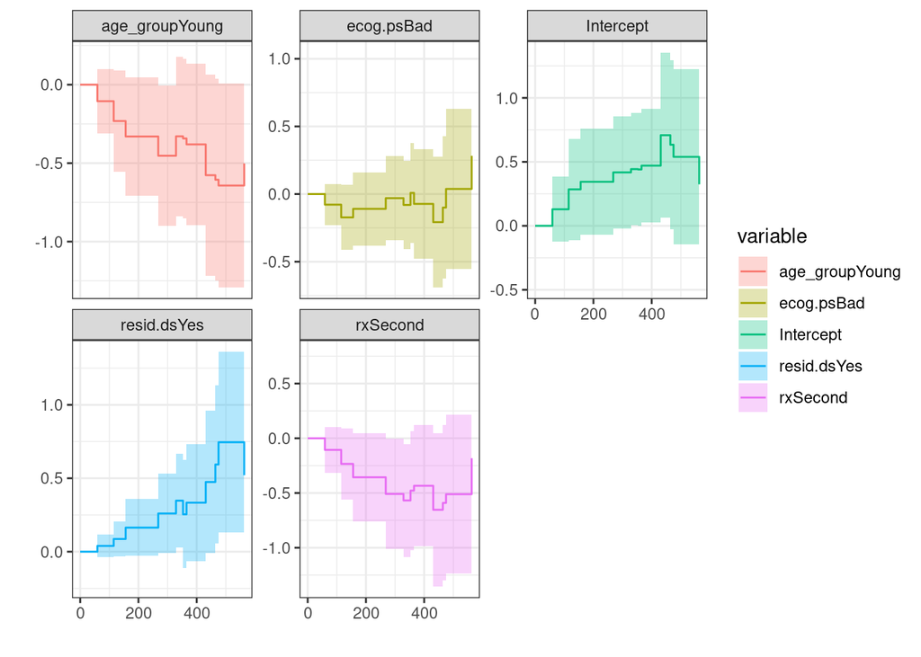

```r
aa_fit <- aareg(km ~ age_group + resid.ds + rx + ecog.ps, data = df)
autoplot(aa_fit)
```

As one can see, Age and Resid.ds variables are indeed may be influenced to some extent

One more type of analysis of factors influencing survival is the Hazard Ratio analysis

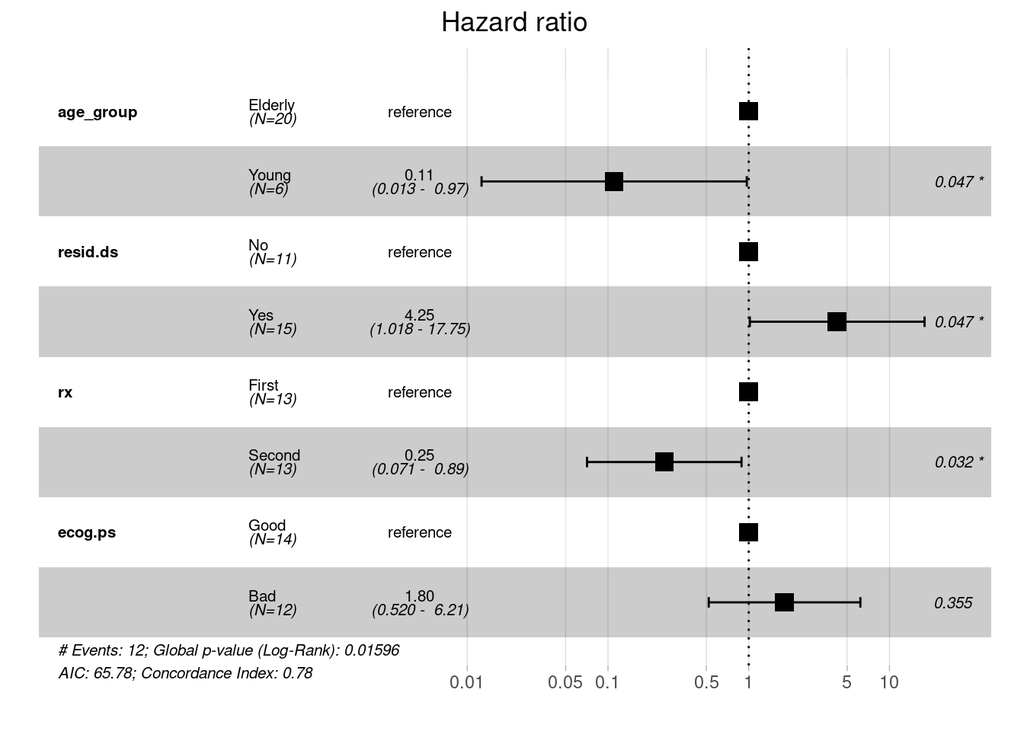

```r
fit.coxph <- coxph(km ~ age_group + resid.ds + rx + ecog.ps, data = df)
ggforest(fit.coxph, data = df)
```

According to the results, being Young, having no residual diseases present, and undergoing second type of treatment, a patient may have greater chances to survive and live longer.

Overall, all testing approaches are well support others methods findings. However, further investigation with larger cohorts are needed to clarify this fundings.